# Lab 2: Spatial Analysis and Visualization

Healthcare Access and Equity in Pennsylvania

Author

Liz Crouse

Published

February 13, 2026

## Assignment Overview

**Learning Objectives:** - Apply spatial operations to answer policy-relevant research questions - Integrate census demographic data with spatial analysis - Create publication-quality visualizations and maps - Work with spatial data from multiple sources - Communicate findings effectively for policy audiences

## Part 1: Healthcare Access for Vulnerable Populations

### Research Question

**Which Pennsylvania counties have the highest proportion of vulnerable populations (elderly + low-income) living far from hospitals?**

Your analysis should identify counties that should be priorities for healthcare investment and policy intervention.

### Required Analysis Steps

Complete the following analysis, documenting each step with code and brief explanations:

#### Step 1: Data Collection (5 points)

Load the required spatial data: - Pennsylvania county boundaries - Pennsylvania hospitals (from lecture data) - Pennsylvania census tracts

**Your Task:**

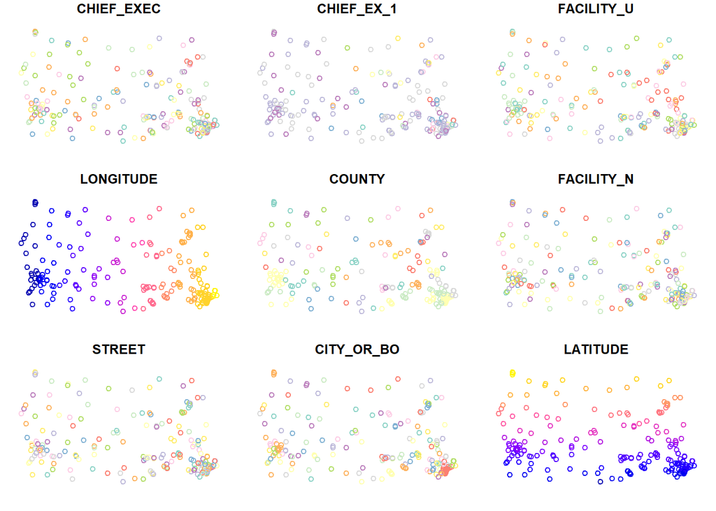

```r
echo = FALSE

# Load required packages
library(tidycensus)
library(tidyverse)
library(stringr)
library(ggplot2)
library(dplyr)
library(tigris)
library(sf)
library(viridis)
library(RColorBrewer)
library(knitr)
library(scales)


# Load spatial data
pa_hospitals <- st_read("C:/Users/lizmc/Desktop/Y2S2/ppa/crouse/labs/lab_2/data/hospitals.geojson")
pa_counties <- st_read("C:/Users/lizmc/Desktop/Y2S2/ppa/crouse/labs/lab_2/data/Pennsylvania_County_Boundaries")
pa_tracts <- tracts("PA")
# Check that all data loaded correctly
plot(pa_hospitals)
```

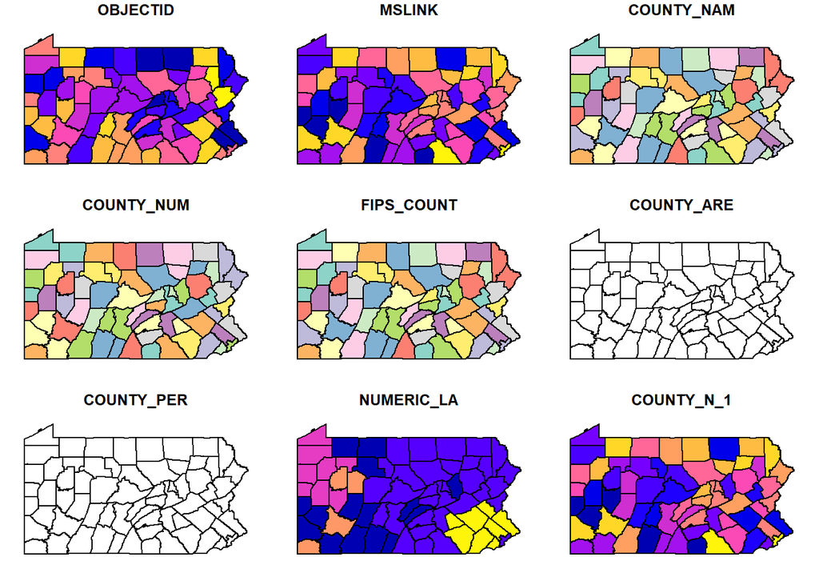

```r
plot(pa_counties)
```

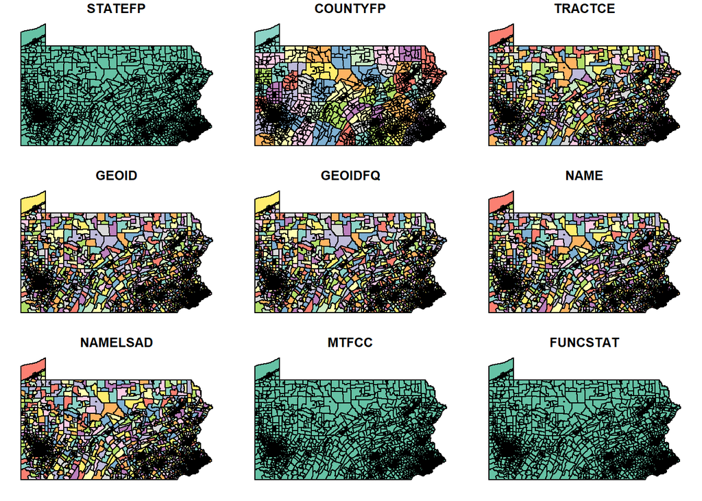

```r
plot(pa_tracts)
```

```r
st_crs(pa_hospitals)
```

```
Coordinate Reference System:
  User input: WGS 84
  wkt:
GEOGCRS["WGS 84",
    DATUM["World Geodetic System 1984",
        ELLIPSOID["WGS 84",6378137,298.257223563,
            LENGTHUNIT["metre",1]]],
    PRIMEM["Greenwich",0,
        ANGLEUNIT["degree",0.0174532925199433]],
    CS[ellipsoidal,2],
        AXIS["geodetic latitude (Lat)",north,
            ORDER[1],
            ANGLEUNIT["degree",0.0174532925199433]],
        AXIS["geodetic longitude (Lon)",east,
            ORDER[2],
            ANGLEUNIT["degree",0.0174532925199433]],
    ID["EPSG",4326]]
```

```r
st_crs(pa_counties)
```

```
Coordinate Reference System:
  User input: WGS 84 / Pseudo-Mercator
  wkt:
PROJCRS["WGS 84 / Pseudo-Mercator",
    BASEGEOGCRS["WGS 84",
        ENSEMBLE["World Geodetic System 1984 ensemble",
            MEMBER["World Geodetic System 1984 (Transit)"],
            MEMBER["World Geodetic System 1984 (G730)"],
            MEMBER["World Geodetic System 1984 (G873)"],
            MEMBER["World Geodetic System 1984 (G1150)"],
            MEMBER["World Geodetic System 1984 (G1674)"],
            MEMBER["World Geodetic System 1984 (G1762)"],
            MEMBER["World Geodetic System 1984 (G2139)"],
            MEMBER["World Geodetic System 1984 (G2296)"],
            ELLIPSOID["WGS 84",6378137,298.257223563,
                LENGTHUNIT["metre",1]],
            ENSEMBLEACCURACY[2.0]],
        PRIMEM["Greenwich",0,
            ANGLEUNIT["degree",0.0174532925199433]],
        ID["EPSG",4326]],
    CONVERSION["Popular Visualisation Pseudo-Mercator",
        METHOD["Popular Visualisation Pseudo Mercator",
            ID["EPSG",1024]],
        PARAMETER["Latitude of natural origin",0,
            ANGLEUNIT["degree",0.0174532925199433],
            ID["EPSG",8801]],
        PARAMETER["Longitude of natural origin",0,
            ANGLEUNIT["degree",0.0174532925199433],
            ID["EPSG",8802]],
        PARAMETER["False easting",0,
            LENGTHUNIT["metre",1],
            ID["EPSG",8806]],
        PARAMETER["False northing",0,
            LENGTHUNIT["metre",1],
            ID["EPSG",8807]]],
    CS[Cartesian,2],
        AXIS["easting (X)",east,
            ORDER[1],
            LENGTHUNIT["metre",1]],
        AXIS["northing (Y)",north,
            ORDER[2],
            LENGTHUNIT["metre",1]],
    USAGE[
        SCOPE["Web mapping and visualisation."],
        AREA["World between 85.06°S and 85.06°N."],
        BBOX[-85.06,-180,85.06,180]],
    ID["EPSG",3857]]
```

```r
st_crs(pa_tracts)
```

```
Coordinate Reference System:
  User input: NAD83
  wkt:
GEOGCRS["NAD83",
    DATUM["North American Datum 1983",
        ELLIPSOID["GRS 1980",6378137,298.257222101,
            LENGTHUNIT["metre",1]]],
    PRIMEM["Greenwich",0,
        ANGLEUNIT["degree",0.0174532925199433]],
    CS[ellipsoidal,2],
        AXIS["latitude",north,
            ORDER[1],
            ANGLEUNIT["degree",0.0174532925199433]],
        AXIS["longitude",east,
            ORDER[2],
            ANGLEUNIT["degree",0.0174532925199433]],
    ID["EPSG",4269]]
```

#### Step 2: Get Demographic Data

Use `tidycensus` to download tract-level demographic data for Pennsylvania.

**Required variables:** - Total population - Median household income - Population 65 years and over (you may need to sum multiple age categories)

**Your Task:**

```r
# Get demographic data from ACS
variables <- c(mhi = "B19013_001",
               pop = "B01003_001",
               m65_66 = "B01001_020",
    m67_69 = "B01001_021",
    m70_74 = "B01001_022",
    m75_79 = "B01001_023",
    m80_84 = "B01001_024",
    m85p   = "B01001_025",

    f65_66 = "B01001_044",
    f67_69 = "B01001_045",
    f70_74 = "B01001_046",
    f75_79 = "B01001_047",
    f80_84 = "B01001_048",
    f85p   = "B01001_049"
  )


tract_demographics <- get_acs(
  geography = "tract",
  state = "PA",
  variables = variables,
  year = 2022,
  survey = "acs5",
  output = "wide"

)
tract_demographics <- tract_demographics %>%
  mutate(
    pop_65plus =
      (m65_66E + m67_69E + m70_74E + m75_79E + m80_84E + m85pE +
      f65_66E + f67_69E + f70_74E + f75_79E + f80_84E + f85pE),

    pct_65plus = (pop_65plus / popE) * 100
  )


# Join to tract boundaries
tract_demographics <- left_join(tract_demographics, pa_tracts, by = "GEOID")

#Initial calculations
sum(is.na(tract_demographics$mhiE))
```

```
[1] 63
```

```r
mean(tract_demographics$mhiE, na.rm = TRUE)
```

```
[1] 77527.23
```

#### Step 3: Define Vulnerable Populations

Identify census tracts with vulnerable populations based on TWO criteria: 1. Low median household income (choose an appropriate threshold) 2. Significant elderly population (choose an appropriate threshold)

**Your Task:**

```r
# Filter for vulnerable tracts based on your criteria
vulnerable_tracts <- tract_demographics %>%
  filter(mhiE < 64300 & pct_65plus > 25)
old_tracts <- tract_demographics %>%
  filter(pct_65plus > 25)
lowinc_tracts <- tract_demographics %>%
  filter(mhiE < 64300)
```

**Questions to answer:** - What income threshold did you choose and why? I chose $64,300 as my low-income threshold because it is 200% of the PA poverty line for a household of four. 200% poverty line is often used as a metric for eligibility for social services, which would likely coincide with the tracts that need additional health services. This represents about 40% of tracts. - What elderly population threshold did you choose and why? I chose 25% because that means at least one in four individuals in the tract are 65+, meaning extra health services may be needed. - How many tracts meet your vulnerability criteria? **230** - What percentage of PA census tracts are considered vulnerable by your definition? 6.7%

#### Step 4: Calculate Distance to Hospitals

For each vulnerable tract, calculate the distance to the nearest hospital.

**Your Task:**

```r
# Transform to appropriate projected CRS
st_geometry(vulnerable_tracts) <- "geometry"
vulnerable_tracts <- vulnerable_tracts %>%
  st_transform(crs = 2272)
pa_hospitals <- pa_hospitals %>%
  st_transform(crs = 2272)
# Calculate distance from each tract centroid to nearest hospital
tract_centroids <- st_centroid(vulnerable_tracts)
vulnerable_tracts <- vulnerable_tracts %>%
  mutate(
    nearest_hosp = st_distance(
      tract_centroids, pa_hospitals$geometry[st_nearest_feature(tract_centroids, pa_hospitals)],
      by_element = TRUE))

vulnerable_tracts <- vulnerable_tracts %>%
  mutate(
    nearest_hosp_miles = as.numeric(nearest_hosp) / 1609.34)

mean(vulnerable_tracts$nearest_hosp_miles, na.rm = TRUE)
```

```
[1] 18.62521
```

```r
tracts_15p <- vulnerable_tracts %>%
  filter(nearest_hosp_miles > 15)
```

**Requirements:** - Use an appropriate projected coordinate system for Pennsylvania - Calculate distances in miles - Explain why you chose your projection **I used EPSG 2272 because it is a project coordinate system specific to the southern part of Pennsylvania, meaning it will provide more accurate measurements.

#### Step 5: Identify Underserved Areas

Define “underserved” as vulnerable tracts that are more than 15 miles from the nearest hospital.

**Your Task:**

```r
# Create underserved variable
vulnerable_tracts <- vulnerable_tracts %>%
  mutate(service_level = case_when(nearest_hosp_miles > 15 ~ "underserved",
            TRUE ~ "served"))
vulnerable_tracts %>%
  count(service_level)
```

```
Simple feature collection with 2 features and 2 fields
Geometry type: MULTIPOLYGON
Dimension:     XY
Bounding box:  xmin: 1204213 ymin: 144992.2 xmax: 2806953 ymax: 1044690
Projected CRS: NAD83 / Pennsylvania South (ftUS)
# A tibble: 2 × 3
  service_level     n                                                   geometry
* <chr>         <int>                            <MULTIPOLYGON [US_survey_foot]>
1 served          139 (((1364680 306535, 1364760 306588.4, 1364926 306701.3, 13…
2 underserved      91 (((1468789 242704.4, 1468958 243992.2, 1469205 246386.1, …
```

#### Step 6: Aggregate to County Level

Use spatial joins and aggregation to calculate county-level statistics about vulnerable populations and hospital access.

**Your Task:**

```r
# Spatial join tracts to counties
pa_counties <- st_transform(pa_counties, st_crs(vulnerable_tracts))
county_statistics <- st_join(vulnerable_tracts, pa_counties["COUNTY_NAM"])

# Aggregate statistics by county

county_statistics_summary <- county_statistics %>%
  group_by(COUNTY_NAM) %>%
  summarise(
    n_vuln_tracts = n(),
    n_unders_tracts = sum(service_level == "underserved", na.rm = TRUE),
    underserved_pct = (n_unders_tracts / n_vuln_tracts) * 100,
    avg_dist_nearest_hosp = mean(nearest_hosp_miles, na.rm = TRUE),
    total_pop_vuln = sum(popE, na.rm = TRUE))

underserved_counties <- county_statistics_summary %>%
  filter(underserved_pct == 100)


countygeo_stat_summary <- pa_counties %>%
  st_join(county_statistics_summary)
```

**Required county-level statistics:** - Number of vulnerable tracts - Number of underserved tracts  
- Percentage of vulnerable tracts that are underserved - Average distance to nearest hospital for vulnerable tracts - Total vulnerable population

**Questions to answer:** - Which 5 counties have the highest percentage of underserved vulnerable tracts? **By my parameters for under-service, there are 17 counties in PA that are entirely underserved. The five with the least service (furthest average distance to nearest hospital) are Dauphin, Perry, Sullivan, Bradford, and Pike Counties.** - Which counties have the most vulnerable people living far from hospitals? **Counties that are 100% underserved with populations greater than 10,000 are Wayne, McKean, Pike, Tioga, and Clarion Counties.** - Are there any patterns in where underserved counties are located? **The largest concentration of the most severely underserved tracts is in north central PA, a rural area distant from PA’s two major population centers of Pittsburgh and Philadelphia.**

#### Step 7: Create Summary Table

Create a professional table showing the top 10 priority counties for healthcare investment.

**Your Task:**

```r
# Create and format priority counties table


underserved_counties_nogeom <- underserved_counties %>%
  st_drop_geometry() %>%
  arrange(desc(avg_dist_nearest_hosp)) %>%
  slice(1:10)

underserved_table <- underserved_counties_nogeom %>%
   mutate(
    n_vuln_tracts = comma(n_vuln_tracts),
    n_unders_tracts = comma(n_unders_tracts),
    total_pop_vuln = comma(total_pop_vuln),
    underserved_pct = percent(underserved_pct / 100, accuracy = 0.1),
    avg_dist_nearest_hosp = round(avg_dist_nearest_hosp, 1)) %>%
  kable(col.names = c("County","# Vulnerable Tracts","# Underserved Tracts","% Tracts Underserved","Average Distance from Tract to Nearest Hospital", "Total Vulnerable Population"), caption = "Counties with high populations of elderly and low income individuals with inequitable access to hospitals")
```

[output not shown]

**Requirements:** - Use `knitr::kable()` or similar for formatting - Include descriptive column names - Format numbers appropriately (commas for population, percentages, etc.) - Add an informative caption - Sort by priority (you decide the metric)

## Part 2: Comprehensive Visualization

Using the skills from Week 3 (Data Visualization), create publication-quality maps and charts.

### Map 1: County-Level Choropleth

Create a choropleth map showing healthcare access challenges at the county level.

**Your Task:**

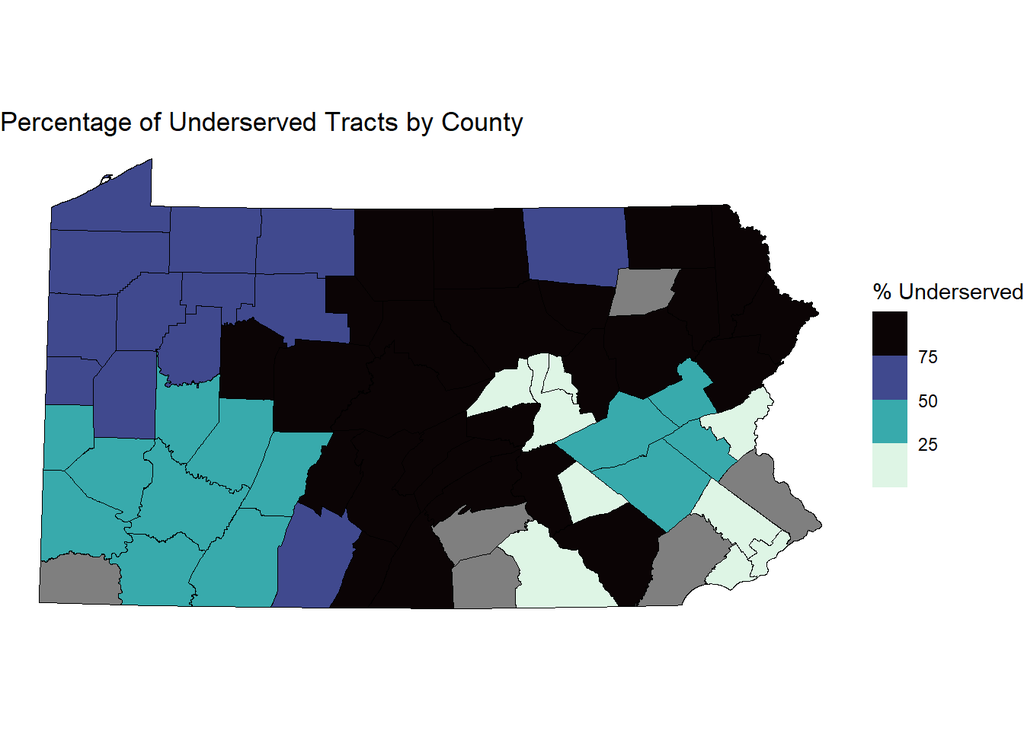

```r
# Create county-level access map

ggplot(countygeo_stat_summary) +
  geom_sf(aes(fill = underserved_pct), color = "black") +
  scale_fill_viridis_b(
    option = "mako",
    direction = -1,
    name =
      "% Underserved") +
  theme_void() +
  labs(title = "Percentage of Underserved Tracts by County")
```

### Map 2: Detailed Vulnerability Map

Create a map highlighting underserved vulnerable tracts.

**Your Task:**

```r
# Create detailed tract-level map
pa_tracts <- pa_tracts %>%
  st_transform(2272)

tracts_service_level <- pa_tracts %>%
  st_join(vulnerable_tracts["service_level"], join = st_within)
tracts_service_level <- tracts_service_level %>%
  mutate(service_level = ifelse(is.na(service_level), "served", service_level))
tracts_service_level %>%
  count(service_level)
```

```
Simple feature collection with 2 features and 2 fields
Geometry type: MULTIPOLYGON
Dimension:     XY
Bounding box:  xmin: 1189586 ymin: 140905.3 xmax: 2814854 ymax: 1165942
Projected CRS: NAD83 / Pennsylvania South (ftUS)
  service_level    n                       geometry
1        served 3355 MULTIPOLYGON (((1318298 149...
2   underserved   91 MULTIPOLYGON (((1468789 242...
```

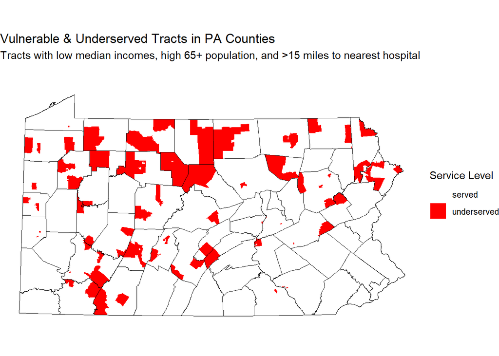

```r
ggplot() +
  geom_sf(
    data = tracts_service_level,
    aes(fill = service_level),
    color = NA) +
  geom_sf(
    data = pa_counties,
    fill = NA,
    color = "black",
    size = 0.2) +
  scale_fill_manual(
    values = c(
      "underserved" = "red",
      "served" = NA),
    na.value = NA) +
  theme_void() +
  labs(
    title = "Vulnerable & Underserved Tracts in PA Counties", subtitle = "Tracts with low median incomes, high 65+ population, and >15 miles to nearest hospital",
    fill = "Service Level")
```

### Chart: Distribution Analysis

Create a visualization showing the distribution of distances to hospitals for vulnerable populations.

**Your Task:**

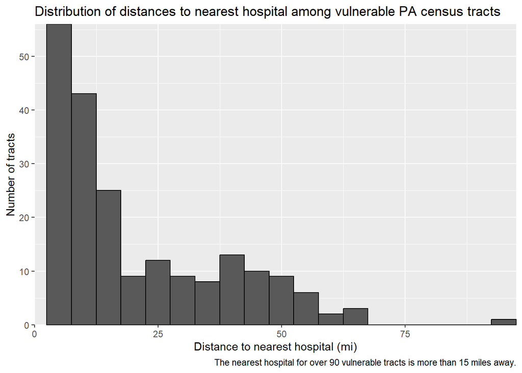

```r
# Create distribution visualization
ggplot(data = vulnerable_tracts, aes(x = nearest_hosp_miles)) +
  geom_histogram(binwidth = 5, color = "black") +
    scale_x_continuous(
    limits = c(0, NA),
    expand = c(0, 0)
  ) +
  scale_y_continuous(
    limits = c(0, NA),
    expand = c(0, 0)) +
     labs(title = "Distribution of distances to nearest hospital among vulnerable PA census tracts",
     x = "Distance to nearest hospital (mi)",
     y = "Number of tracts",
     caption = "The nearest hospital for over 90 vulnerable tracts is more than 15 miles away.")
```

**Suggested chart types:** - Histogram or density plot of distances - Box plot comparing distances across regions - Bar chart of underserved tracts by county - Scatter plot of distance vs. vulnerable population size

**Requirements:** - Clear axes labels with units - Appropriate title - Professional formatting - Brief interpretation (1-2 sentences as a caption or in text)

## Part 3: Bring Your Own Data Analysis

```r
# Load your additional dataset

phl <- counties(state = "PA")
phl <- phl %>%
  filter(NAMELSAD == "Philadelphia County")
phl <- phl %>% st_transform(2272)

crime_phl <- st_read("C:/Users/lizmc/Desktop/Y2S2/ppa/crouse/labs/lab_2/data/incidents_part1_part2(1)")
```

```
replacing null geometries with empty geometries
Simple feature collection with 152556 features and 13 fields (with 3718 geometries empty)
Geometry type: POINT
Dimension:     XY
Bounding box:  xmin: -75.27421 ymin: 5.684342e-14 xmax: 5.684342e-14 ymax: 40.13718
Geodetic CRS:  WGS 84
```

```r
crime_phl <- crime_phl %>% st_transform(2272)
crime_phl <- st_filter(crime_phl, phl)

schools_phl <- st_read("C:/Users/lizmc/Desktop/Y2S2/ppa/crouse/labs/lab_2/data/Schools")
schools_phl <- schools_phl %>% st_transform(2272)
```

2. **Pose a research question** Which school zones are surrounded by the most (reported) crime?
3. **Conduct spatial analysis**

Use at least TWO spatial operations to answer your research question.

**Required operations (choose 2+):** - Buffers - Spatial joins - Spatial filtering with predicates - Distance calculations - Intersections or unions - Point-in-polygon aggregation

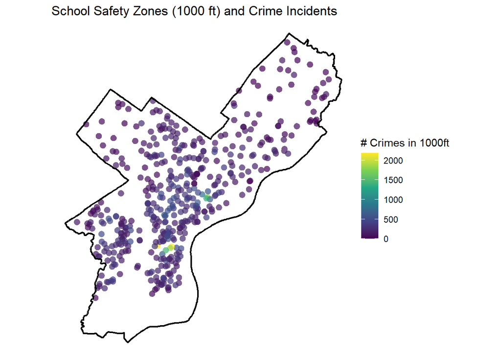

```r
#Clean dataset by eliminating duplicates

schools_phl <- schools_phl %>%
  filter(!is.na(school_nam), school_nam != "")
schools_unique <- schools_phl %>%
  group_by(school_nam) %>%
  summarise(
    geometry = st_union(geometry),
    .groups = "drop")

#Create buffers
school_buffers <- st_buffer(schools_unique, dist = 1000)

#Join with crime data
crime_in_school_zones <- st_join(
  crime_phl,
  school_buffers,
  join = st_within,
  left = FALSE)

#Count number of crimes in buffer zones (point in polygon)
crime_by_school <- crime_in_school_zones %>%
  group_by(school_nam) %>%
  summarise(
    n_crimes = n(),
    .groups = "drop")

#Spatial join back to buffers
school_buffers_crime <- school_buffers %>%
  left_join(
    st_drop_geometry(crime_by_school),
    by = "school_nam") %>%
  mutate(
    n_crimes = replace_na(n_crimes, 0))

#Plot density of crimes in school buffer zones
ggplot() +
  geom_sf(data = school_buffers_crime,
          aes(fill = n_crimes),
          color = "NA",
          alpha = 0.7) +
    geom_sf(data = phl,
    fill = NA,
    color = "black",
    linewidth = 0.8) +
  scale_fill_viridis_c(name = "# Crimes in 1000ft") +
  theme_void() +
  labs(title = "School Safety Zones (1000 ft) and Crime Incidents")
```

```r
#Identify school zones with the highest number of crimes for potential interventions
highest_risk_schools <- school_buffers_crime %>%
  st_drop_geometry() %>%
  slice_max(n_crimes, n= 10)

highest_risk_table <- highest_risk_schools %>%
  kable(col.names = c("School Name", "# of reported crimes in 1000 ft radius (2025)"), caption = "Schools with the most reported crimes within 1000 foot radius, 2025")
```

[output not shown]

**Analysis requirements:** - Clear code comments explaining each step - Appropriate CRS transformations - Summary statistics or counts - At least one map showing your findings - Brief interpretation of results (3-5 sentences)